# session_02b

## Week 2b: Analysing and exploring data

*Keywords*: pandas, explorative data analysis

We are going to use the pandas library for python to analyse and explore some data. You can find more information about the pandas here:

https://pandas.pydata.org/pandas-docs/stable/index.html

The data you are using in the first exercise are from kaggle, which hosts numerous datasets that are useful and fun to explore. Today, we will look at data from the titanic:

https://www.kaggle.com/c/titanic/data

Go to kaggle, register and download the data files train.csv and test.csv. In general, it is a good idea to organise your working directory such that you have a separate folder for your data. In this example, I've saved the files in the 'data' directory.

```python
import numpy as np
import pandas as pd
import matplotlib.pyplot as plt
import scipy.stats as stats
import statsmodels.stats.proportion as proportions

# enable inline plotting
%matplotlib inline
```

#### Exercise:

- Load both datasets with pandas using read_csv()
- Get an overview of the data using the info(), head(), describe() methods of your dataframe object.
- Display only parts of the data: i) the first three rows ii) the 'age' column. Remember that if your dataframe is df, you can call a column by using df["column_name"].

```python
# to-do: load the datasets with pandas
train_df = pd.read_csv("data/train.csv")
test_df = pd.read_csv("data/test.csv")
```

The dataframes have been created automatically. It's a good idea to first get an overview of the data. What kind of data are we dealing with in the different columns?

```python
# to-do: get an overview of the data
print("train df", train_df.head())
print("test df", test_df.head())
```

```
train df    PassengerId  Survived  Pclass  \
0            1         0       3
1            2         1       1
2            3         1       3
3            4         1       1
4            5         0       3

                                                Name     Sex   Age  SibSp  \
0                            Braund, Mr. Owen Harris    male  22.0      1
1  Cumings, Mrs. John Bradley (Florence Briggs Th...  female  38.0      1
2                             Heikkinen, Miss. Laina  female  26.0      0
3       Futrelle, Mrs. Jacques Heath (Lily May Peel)  female  35.0      1
4                           Allen, Mr. William Henry    male  35.0      0

   Parch            Ticket     Fare Cabin Embarked
```

[output cut: 18 more lines]

You can easily show only a certain range of the data or choose columns.

```python
# to-do: display the first three rows
print(train_df.iloc[0:3, :])
```

```
   PassengerId  Survived  Pclass  \
0            1         0       3
1            2         1       1
2            3         1       3

                                                Name     Sex   Age  SibSp  \
0                            Braund, Mr. Owen Harris    male  22.0      1
1  Cumings, Mrs. John Bradley (Florence Briggs Th...  female  38.0      1
2                             Heikkinen, Miss. Laina  female  26.0      0

   Parch            Ticket     Fare Cabin Embarked
0      0         A/5 21171   7.2500   NaN        S
1      0          PC 17599  71.2833   C85        C
2      0  STON/O2. 3101282   7.9250   NaN        S
```

```python
# to-do: display the 'age' column
print(train_df["Age"])
```

```
0      22.0
1      38.0
2      26.0
3      35.0
4      35.0
       ...
886    27.0
887    19.0
888     NaN
889    26.0
890    32.0
Name: Age, Length: 891, dtype: float64
```

As you can see, some of the age data is missing. This might cause some issues down the road if you're analysing your data. Always be sure to check your data for missing/weird data. You can use the dropna() method to get rid of missing entries.

```python
df_train_cleaned = train_df.dropna(subset=['Age'])
df_test_cleaned = test_df.dropna(subset=['Age'])
df_train_cleaned['Age'].values
```

[output not shown]

[output cut: 25 more lines]

[output not shown]

Sometimes it might be useful to turn parts of your dataframe into a numpy array.

```python
arr = df_train_cleaned['Age'].to_numpy(dtype='int')
# for older pandas versions: np.asarray(df_train_cleaned['Age'], dtype='int')
```

There's many useful functions you can apply to your dataframe.

```python
df_train_cleaned['Age'].mean()
```

```
29.69911764705882
```

It can often be very useful to combine dataframes. Take a look at the concat function: https://pandas.pydata.org/pandas-docs/stable/generated/pandas.concat.html

```python
help(pd.concat)
```

[output not shown]

[output cut: 137 more lines]

[output not shown]

```python
# this creates a list of dataframes
df_list = [train_df, test_df]
print(type(df_list))

# combine the two dataframes
df_combined = pd.concat(df_list, sort=True)
df_combined.describe()
```

```
<class 'list'>
```

|  | Age | Fare | Parch | PassengerId | Pclass | SibSp | Survived |
| --- | --- | --- | --- | --- | --- | --- | --- |
| count | 1046.000000 | 1308.000000 | 1309.000000 | 1309.000000 | 1309.000000 | 1309.000000 | 891.000000 |
| mean | 29.881138 | 33.295479 | 0.385027 | 655.000000 | 2.294882 | 0.498854 | 0.383838 |
| std | 14.413493 | 51.758668 | 0.865560 | 378.020061 | 0.837836 | 1.041658 | 0.486592 |
| min | 0.170000 | 0.000000 | 0.000000 | 1.000000 | 1.000000 | 0.000000 | 0.000000 |
| 25% | 21.000000 | 7.895800 | 0.000000 | 328.000000 | 2.000000 | 0.000000 | 0.000000 |
| 50% | 28.000000 | 14.454200 | 0.000000 | 655.000000 | 3.000000 | 0.000000 | 0.000000 |
| 75% | 39.000000 | 31.275000 | 0.000000 | 982.000000 | 3.000000 | 1.000000 | 1.000000 |
| max | 80.000000 | 512.329200 | 9.000000 | 1309.000000 | 3.000000 | 8.000000 | 1.000000 |

At some point it's a good idea to store your modified dataframe to disk. The function to_csv() will save your dataframe as a .csv file.

```python
# write the combined dataframe as a csv file
df_combined.to_csv('./data/combined.csv', index=False)
```

Let's get into some data exploration. There are many built-in functions that allow quick-and-dirty plotting directly from dataframes.

#### Exercise:

- Make a histogram of the 'Age' and 'Pclass' columns using your_dataframe.hist().
- Take a look at the parameters hist(). Make a normalized histogram of the 'age' column. Overplot a kde (kernel density estimate) for the pdf (probability density function).

```
array([[<AxesSubplot:title={'center':'Pclass'}>]], dtype=object)
```

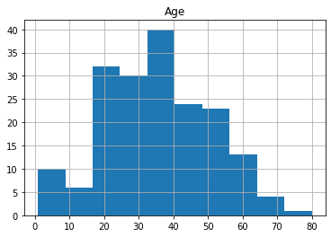

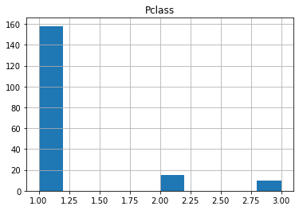

```python
# to-do: make histograms
df_combined = df_combined.dropna()
plt.figure()
df_combined.hist("Age")
plt.figure()
df_combined.hist("Pclass")
```

Sometimes it is useful to plot the normalized histogram along with a kde (kernel density estimate) for the pdf (probability density function).

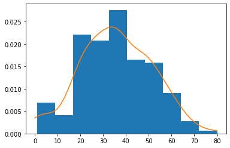

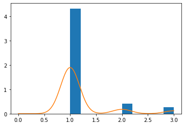

```python
# to-do: make a normalized histogram and overplot the kde
kde_age = stats.gaussian_kde(df_combined["Age"])
xs = np.linspace(0,80,200)
plt.figure()
plt.hist(df_combined["Age"], density=True)
plt.plot(xs, kde_age(xs))

kde_pclass = stats.gaussian_kde(df_combined["Pclass"])
xs = np.linspace(0,3.0,200)
plt.figure()
plt.hist(df_combined["Pclass"], density=True)
plt.plot(xs, kde_pclass(xs))
```

Let's modify the class counts histogram a bit more to make it prettier. The x-values are not quite in the correct place, which is easily fixable.

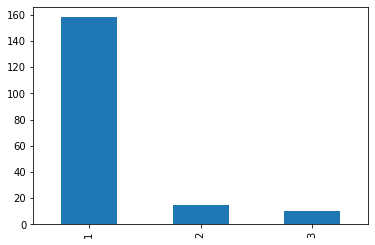

```python
class_counts = df_combined['Pclass'].value_counts()
class_counts.plot(kind='bar')
```

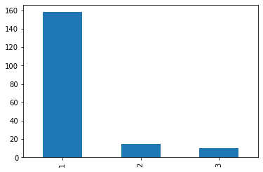

```python
class_counts.sort_index().plot(kind='bar')
```

The **groupby** function can be very useful, but it is not very obvious how to use it. You can find some information and tutorials below.

https://pandas.pydata.org/pandas-docs/stable/groupby.html

http://nbviewer.jupyter.org/urls/bitbucket.org/hrojas/learn-pandas/raw/master/lessons/02%20-%20Lesson.ipynb

With the power of groupby, you can easily answer questions such as: What is the average age of those who survived?

```python
survived = df_combined.groupby('Survived')
survived['Age'].mean()
```

```
Survived
0.0    41.350000
1.0    32.905854
Name: Age, dtype: float64
```

#### Exercise:

Now it's your turn. You are encouraged to tackle the following exercises in groups.

- Explore the data and make some plots. Try a few different types of plots, for example scatter plots, histograms and bar charts. Be creative!
- What is the age of the oldest survivor?
- What fraction of men/women survived (died)?
- What fraction of of children survived (died)?
- What fraction of passengers from 1st/2nd/3rd class survived? Are any of these differences statistically signifcant?
- Look for a correlation between fare and survival probability.
- You can also load the data into R and do a similar analysis.
- If you have time, you can go to kaggle and explore a data set that seems interesting to you.

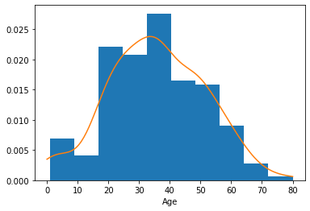

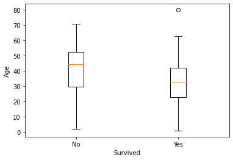

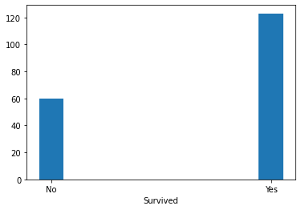

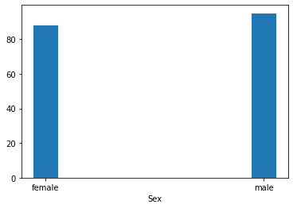

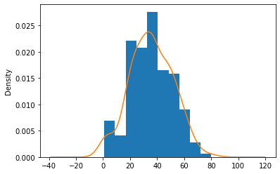

```python
# to-do: explore the data and make some plots
xs = np.linspace(0,80,200)
plt.figure()
plt.hist(df_combined['Age'], density=True)
plt.plot(xs, kde_age(xs))
plt.xlabel("Age")

data_age = [df_combined.loc[df_combined["Survived"] == 0.0, "Age"],
            df_combined.loc[df_combined["Survived"] == 1.0, "Age"]]
fig1, ax1 = plt.subplots()
ax1.boxplot(data_age)
plt.xticks([1,2], labels=["No", "Yes"])
plt.xlabel("Survived")
plt.ylabel("Age")

plt.figure()
plt.hist(df_combined['Survived'])
plt.xticks([0.05,0.95], labels=["No", "Yes"])
plt.xlabel("Survived")

plt.figure()
plt.hist(df_combined['Sex'])
plt.xticks([0.05,0.95])
plt.xlabel("Sex")

# other way of getting kde plot
plt.figure()
df_combined["Age"].hist(density=True)
df_combined["Age"].plot.kde()
```

```python
# to-do: what is the age of the oldest survivor?
print(max(df_combined.loc[df_combined["Survived"]==1.0, "Age"]))
```

```
80.0
```

```python
# to-do: what fraction of men/women survived?
tot_male = df_combined[df_combined["Sex"]=="male"].count()[0]
survived_male = df_combined.loc[(df_combined["Sex"]=="male") & (df_combined["Survived"]==1.0)].count()[0]
tot_female = df_combined[df_combined["Sex"]=="female"].count()[0]
survived_female = df_combined.loc[(df_combined["Sex"]=="female") & (df_combined["Survived"]==1.0)].count()[0]

fraction_survived = pd.DataFrame({"Sex" : ["male", "female"],
                                "survived fraction" : [survived_male/tot_male, survived_female/tot_female]})
print(fraction_survived)
```

```
      Sex  survived fraction
0    male           0.431579
1  female           0.931818
```

```python
# to-do: what fraction of children survived?
# defined child as below the age of 18
tot_child = df_combined[df_combined["Age"]<18.0].count()[0]
survived_child = df_combined.loc[(df_combined["Age"]<18.0) & (df_combined["Survived"]==1.0)].count()[0]
print("fraction of children that survived {:.2f}".format(survived_child/tot_child))
```

```
fraction of children that survived 0.89
```

```python
# to-do: what fraction of passengers from 1st/2nd/3rd class survived, and are
# any of the differences statistically significant?
pclass = df_combined[["Pclass"]].groupby("Pclass").size().reset_index(name="counts")
pclass_surv = df_combined.loc[df_combined["Survived"] == 1.0,:].groupby("Pclass").size().reset_index(name="counts")
prop = (pclass_surv/pclass)["counts"]
print(prop)

# using z-test for proportions
pclass = np.asarray(pclass["counts"], dtype="int")
pclass_surv = np.asarray(pclass_surv["counts"], dtype="int")
res_prop_test1 = proportions.proportions_ztest(count=pclass_surv[0:2], nobs=pclass[0:2], value=0.0)
res_prop_test2 = proportions.proportions_ztest(count=pclass_surv[1:], nobs=pclass[1:], value=0.0)

print(res_prop_test1)
print(res_prop_test2)
```

```
0    0.670886
1    0.800000
2    0.500000
Name: counts, dtype: float64
(-1.026237680459015, 0.304779564239708)
(1.575315094531511, 0.11518373151505122)
```

```
array([<AxesSubplot:title={'center':'0.0'}>,
       <AxesSubplot:title={'center':'1.0'}>], dtype=object)
```

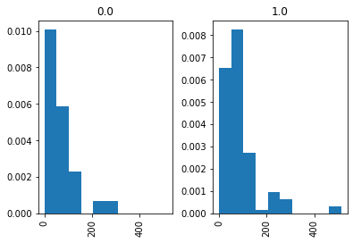

```python
# to-do: look for a correlation between fare and survival probability.
df_combined["Fare"].hist(by=df_combined["Survived"], range=(0,df_combined["Fare"].max()), density=True)
```